# Tipping_behavior

Author

Bargieł Izabela and Hryniewicka Hanna and Quast Jonathan and Wewiór Mikołaj

# Title and authors

## Title:

Tipping behavior

## Authors:

- Izabela Bargieł, Warsaw University of Technology (WUT), `izabela.bargiel.stud@pw.edu.pl`
- Hanna Hryniewicka, Warsaw University of Technology (WUT), `hanna.hryniewicka.stud@pw.edu.pl`
- Jonathan Quast, Delft University of Technical (TU Delft), `j.n.quast@student.tudelft.nl`
- Mikołaj Wewiór, Warsaw University of Technology (WUT), `mikolaj.wewior.stud@pw.edu.pl`

# Research question

## Main question:

> What drives tipping behavior in restaurants

## Subquestions:

- Q1 [`dplyr`]: What are the average and median tip amounts and what proportion of customers leave a tip of at least 20%?
- Q2 [`dplyr`]: Which parties (f. ex. smoking women) tipped highest and which the lowest?
- Q3 [`dplyr`]: How do lunch and dinner compare on average bill, tip and number of parties?
- Q4 [`dplyr`]: Which shift is busiest, and which is most generous?
- Q5 [`ggplot2`]: What is the relationship between the total bill amount and the tip amount?
- Q6 [`ggplot2`]: Where should the waiter want to be?
- Q7 [`ggplot2`]: Do tips and tip percentages differ between days of the week and between lunch and dinner?
- Q8 [`ggplot2`]: Are smokers really less predictable tippers than non-smokers?

# Dataset

The dataset that we use is a `tips` dataset. It is available on kaggle.com (https://www.kaggle.com/datasets/saurabhbadole/restaurant-tips-dataset).

| feature | short description |
| --- | --- |
| number of rows | $244$ |
| number of columns | $7$ |
| key variables | `total_bill`, `tip` |
| other variables | `sex`, `smoker`, `day`, `time`, `size` |
| missing values | None |
| cleaning | None |

# Analysis

## Setup

```r
library(tidyverse)
tips <- read_csv("tips.csv")
```

```r
glimpse(tips)
```

```
Rows: 244
Columns: 7
$ total_bill <dbl> 16.99, 10.34, 21.01, 23.68, 24.59, 25.29, 8.77, 26.88, 15.0…
$ tip        <dbl> 1.01, 1.66, 3.50, 3.31, 3.61, 4.71, 2.00, 3.12, 1.96, 3.23,…
$ sex        <chr> "Female", "Male", "Male", "Male", "Female", "Male", "Male",…
$ smoker     <chr> "No", "No", "No", "No", "No", "No", "No", "No", "No", "No",…
$ day        <chr> "Sun", "Sun", "Sun", "Sun", "Sun", "Sun", "Sun", "Sun", "Su…
$ time       <chr> "Dinner", "Dinner", "Dinner", "Dinner", "Dinner", "Dinner",…
$ size       <dbl> 2, 3, 3, 2, 4, 4, 2, 4, 2, 2, 2, 4, 2, 4, 2, 2, 3, 3, 3, 3,…
```

```r
head(tips)
```

```
# A tibble: 6 × 7
  total_bill   tip sex    smoker day   time    size
       <dbl> <dbl> <chr>  <chr>  <chr> <chr>  <dbl>
1       17.0  1.01 Female No     Sun   Dinner     2
2       10.3  1.66 Male   No     Sun   Dinner     3
3       21.0  3.5  Male   No     Sun   Dinner     3
4       23.7  3.31 Male   No     Sun   Dinner     2
5       24.6  3.61 Female No     Sun   Dinner     4
6       25.3  4.71 Male   No     Sun   Dinner     4
```

### dplyr

> Q1: What are the average and median tip amounts and what proportion of customers leave a tip of at least 20%?

```r
tips<-tips |>
  mutate(percentage=round(100*tip/total_bill))

tips|>
  summarize(
    mean_tip                = round(mean(tip),2),
    median_tip              = round(median(tip),2),
    mean_tip_percentage     = round(mean(percentage)),
    median_tip_percentage   = round(median(percentage)),
    pctg_of_tips_above_20p  = round(100 * sum(percentage > 20) / n())
  )
```

```
# A tibble: 1 × 5
  mean_tip median_tip mean_tip_percentage median_tip_percentage
     <dbl>      <dbl>               <dbl>                 <dbl>
1        3        2.9                  16                    16
# ℹ 1 more variable: pctg_of_tips_above_20p <dbl>
```

*findings*: On average, a party tipped about $3.00 (median $2.90), which is roughly 16% of the bill (median about 15.5%). About 16% of parties (39 of 244) tipped at least 20%.

> Q2: Which parties (f. ex. smoking women) tipped highest and which the lowest?

```r
tips <- tips |>
  mutate(percent_tip = tip / (tip + total_bill) * 100)

tips |>
  group_by(sex, smoker) |>
  summarise(
    n              = n(),
    mean_tip       = round(mean(tip), 2),
    median_tip     = round(median(tip), 2),
    mean_tip_pct   = round(mean(percent_tip), 2),
    median_tip_pct = round(median(percent_tip), 2),
    sd_tip_pct     = round(sd(percent_tip), 2),
    .groups        = "drop"
  ) |>
  arrange(desc(mean_tip))
```

```
# A tibble: 4 × 8
  sex    smoker     n mean_tip median_tip mean_tip_pct median_tip_pct sd_tip_pct
  <chr>  <chr>  <int>    <dbl>      <dbl>        <dbl>          <dbl>      <dbl>
1 Male   No        97     3.11       2.74         13.7           13.6       3.08
2 Male   Yes       60     3.05       3            12.8           12.4       5.53
3 Female Yes       33     2.93       2.88         15.1           14.8       4.9
4 Female No        54     2.77       2.68         13.5           13.0       2.77
```

*findings*: By dollars, male non-smokers tipped the most ($3.11 on average) and female non-smokers the least ($2.77), but the gaps are small. By tip percentage, female smokers tipped the highest share and male smokers the lowest (15.1% vs 12.8% of the total paid), so the ranking depends on the measure.

> Q3: How do lunch and dinner compare on average bill, tip and number of parties?

```r
tips |>
  mutate(
    bill_per_person = total_bill / size,
    tip_per_person = tip / size,
    tip_percentage = tip / total_bill * 100,
  ) |>
  group_by(time) |>
  summarise(
    n_parties   = n(),
    avg_bill_pp = round(mean(bill_per_person), 2),
    avg_tip_pp  = round(mean(tip_per_person), 2),
    avg_bill    = round(mean(total_bill), 2),
    median_bill = round(median(total_bill), 2),
    avg_tip     = round(mean(tip), 2),
    median_tip  = round(median(tip), 2),
    avg_tip_pct = round(mean(tip_percentage), 2),
  ) |>
  arrange(
    case_when(
      time == "Lunch"  ~ 1,
      time == "Dinner" ~ 2,
      .default = 9
    )
  )
```

```
# A tibble: 2 × 9
  time  n_parties avg_bill_pp avg_tip_pp avg_bill median_bill avg_tip median_tip
  <chr>     <int>       <dbl>      <dbl>    <dbl>       <dbl>   <dbl>      <dbl>
1 Lunch        68        7.32       1.18     17.2        16.0    2.73       2.25
2 Dinn…       176        8.11       1.23     20.8        18.4    3.1        3
# ℹ 1 more variable: avg_tip_pct <dbl>
```

*findings*: Dinner has far more parties than lunch (176 vs 68) and higher average bills (20.80$ vs 17.17$) and tips (3.10$ vs 2.73$). The tip percentage is almost the same (about 16.0% vs 16.4%), so dinner tips are bigger because the bills are bigger, not because diners are more generous

> Q4: Which shift is busiest, and which is most generous?

```r
# Add columns for tip percentage of total bill (per table)
tips <- tips |> mutate(
  tip_pct = tip / total_bill * 100
  )

# Summarise the shifts
shift_summary <- tips |> group_by(day, time) |>
  summarise(
    tables       = n(),
    guests       = sum(size),
    avg_tip      = mean(tip),
    avg_tip_pct  = mean(tip_pct),
    total_tips   = sum(tip),
    .groups = "drop"
  )
```

```r
# Arrange the summary to reveal the busiest shift (most tables) and the most generous shift (highest average tipping percentage)
shift_summary |> arrange(desc(tables))      # busiest
```

```
# A tibble: 6 × 7
  day   time   tables guests avg_tip avg_tip_pct total_tips
  <chr> <chr>   <int>  <dbl>   <dbl>       <dbl>      <dbl>
1 Sat   Dinner     87    219    2.99        15.3      260.
2 Sun   Dinner     76    216    3.26        16.7      247.
3 Thur  Lunch      61    150    2.77        16.1      169.
4 Fri   Dinner     12     26    2.94        15.9       35.3
5 Fri   Lunch       7     14    2.38        18.9       16.7
6 Thur  Dinner      1      2    3           16.0        3
```

```r
shift_summary |> arrange(desc(avg_tip_pct)) # most generous
```

```
# A tibble: 6 × 7
  day   time   tables guests avg_tip avg_tip_pct total_tips
  <chr> <chr>   <int>  <dbl>   <dbl>       <dbl>      <dbl>
1 Fri   Lunch       7     14    2.38        18.9       16.7
2 Sun   Dinner     76    216    3.26        16.7      247.
3 Thur  Lunch      61    150    2.77        16.1      169.
4 Thur  Dinner      1      2    3           16.0        3
5 Fri   Dinner     12     26    2.94        15.9       35.3
6 Sat   Dinner     87    219    2.99        15.3      260.
```

*findings*: Saturday dinner is the busiest shift (87 tables) and Sunday dinner is the most generous in dollars ($3.26 average tip, 16.7%). Friday lunch has the highest tip percentage (18.9%), but it has only 7 tables, and Thursday dinner has just 1 table, so neither should be over-interpreted.

### ggplot2

> Q5: What is the relationship between the total bill amount and the tip amount?

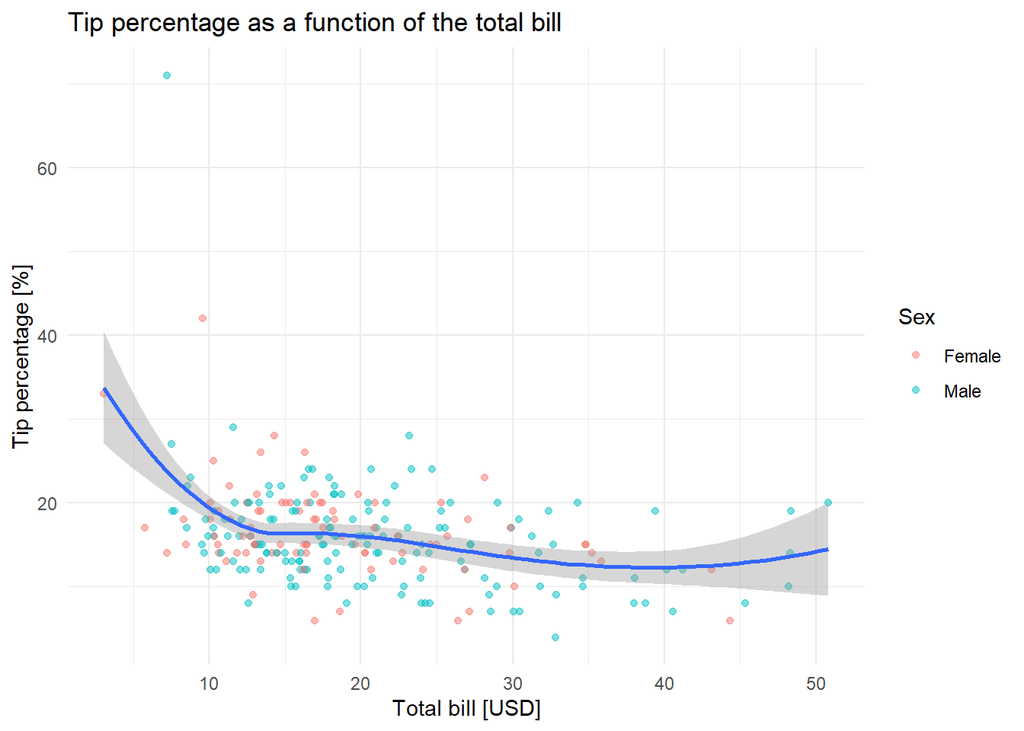

```r
tips|>
  ggplot(
    aes(x=total_bill,y=percentage)
  )+
  geom_point(
    aes(color=factor(sex)),  alpha=0.5
  )+
  geom_smooth()+
  labs(
    title = "Tip percentage as a function of the total bill",
    x = "Total bill [USD]",
    y = "Tip percentage [%]",
    color = "Sex"
  )+
  theme_minimal()
```

> Q6: Where should the waiter want to be?

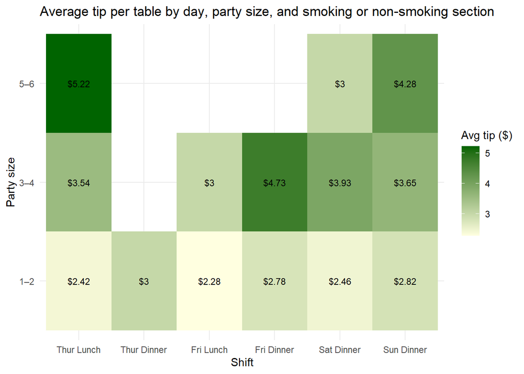

```r
# Create columns for shifts (day + time, sorted by time) and group size (in size steps of 2)
tip_by_table_summary <- tips |>
  mutate(
    shift = factor(paste(day, time),
                   levels = c("Thur Lunch", "Thur Dinner", "Fri Lunch",
                              "Fri Dinner", "Sat Dinner", "Sun Dinner")),
    group_size = cut(size, breaks = c(0, 2, 4, 6), labels = c("1–2", "3–4", "5–6")))

tip_by_table_summary <- tip_by_table_summary |>
  group_by(shift, group_size) |>
  summarise(
    tables  = n(),
    avg_tip = mean(tip),
    .groups = "drop"
  )

# Create a heatmap (geom_tile) showing the average tip by shift party size
tip_by_table_summary |> ggplot(aes(x = shift, y = group_size, fill = avg_tip)) +
  geom_tile() +
  geom_text(aes(label = paste0("$", round(avg_tip, 2))), size = 3) +
  scale_fill_gradient(low = "lightyellow", high = "darkgreen") +
  labs(
    title =
      "Average tip per table by day, party size, and smoking or non-smoking section",
    x = "Shift", y = "Party size", fill = "Avg tip ($)"
  ) +
  theme_minimal()
```